# Impacts of Loan Characterics on Borrower's APR

## by Nick Webb

## Investigation Overview

> Using ProsperLoan dataset I will be investigating how borrowers characteristcs change over time and the Borrower's APR will be analyzied against many factors such as; the borrower's rating, score, occupation and income that could influence change in borrower's APR. The Prosper Rating and score could correlate with a low Borrower's APR. One could assume the higher rating to reflect a more trustworthy customer.

## Dataset Overview

> This dataset contains a total of 113,937 loans entries and 81 attributes. Each loan contains information on the borrower's background information and details regarding the loan.

## Univariate Exploration

> To get an understanding of our data, we will start by looking at the quantity of listings by state level.

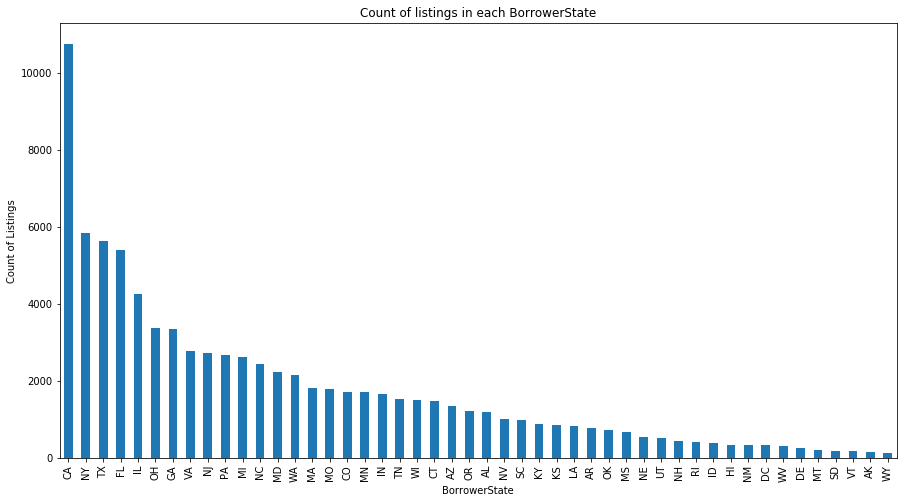

```python
# plotting bar graph of Count of listings in each BorrowerState
color = sb.color_palette()[0]
plt.figure(figsize=(15, 8))
states_cnt.plot(kind='bar', color=color);

plt.title('Count of listings in each BorrowerState');
plt.xlabel('BorrowerState');
plt.ylabel('Count of Listings');
plt.xticks(rotation=90);
```

The states with the most borrowers are California, Texas, New York, and Florida. The interesting thing here is the fact that so many more of the listings came from California.')

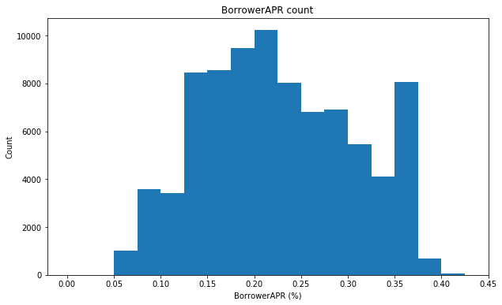

```python
# see the counts for all BorrowerAPR values
plt.figure(figsize = (10, 6))
bins = np.arange(0, df_copy['BorrowerAPR'].max()+ 0.025, 0.025)
plt.hist(data = df_copy, x = 'BorrowerAPR', bins = bins)
plt.title('BorrowerAPR count')
plt.xlabel('BorrowerAPR (%)')
plt.ylabel('Count')
plt.xticks(np.arange(0, df_copy['BorrowerAPR'].max()+0.05, 0.05));
```

The average interest rate on these loans is 19.6%, which is very high. The interests rates for the loans are almost as high as a credit card. Must figure out the reason for debt consolidation loan with a similair interest rate as a credit card.

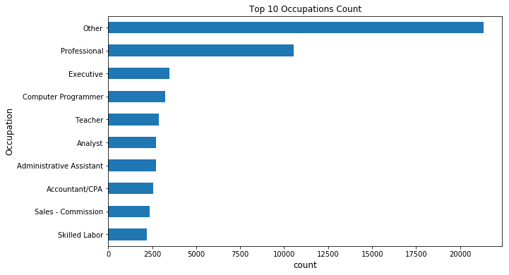

```python
# The top 10 occupations of borrowers
df_copy['Occupation'].value_counts()[9::-1].plot(kind='barh', color =sb.color_palette()[0], figsize=(10,6))
plt.title('Top 10 Occupations Count')
plt.xlabel('count', fontsize=12)
plt.ylabel('Occupation', fontsize=12)
plt.fontsize = 20
```

It is no surprise that "Other" and "Professional" have the highest counts. Often, given the option, individuals would rather not disclose more information than necessary.

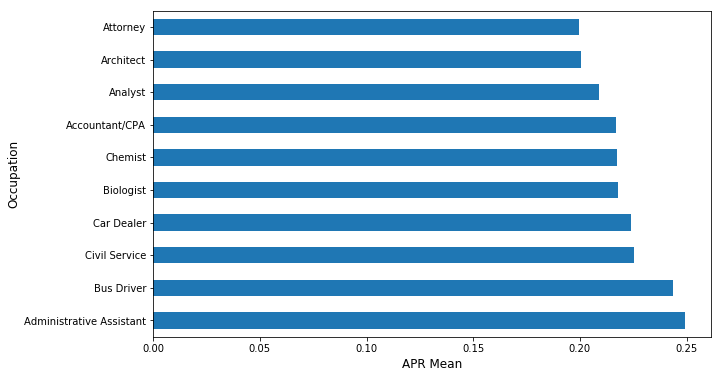

```python
# Top 10 APR means by occupations
base_color = sb.color_palette()[0]
borrower_mean_api.sort_values(ascending=False).plot(kind='barh', color = base_color, figsize=(10,6),)
plt.xlabel('APR Mean', fontsize=12)
plt.ylabel('Occupation', fontsize=12)
```

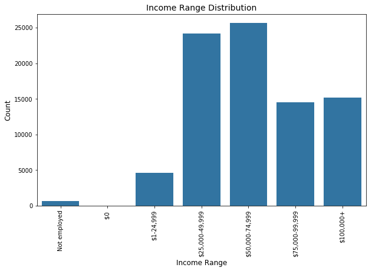

```python
plt.figure(figsize=(10,6))
sb.countplot(data = df_copy, x = 'IncomeRange', color = base_color)
plt.title('Income Range Distribution', fontsize=14)
plt.xlabel('Income Range', fontsize=12)
plt.ylabel('Count', fontsize=12)
plt.xticks(rotation = 90);
```

From the bar chart above, we can see the majority of the listings fall within the income range of $25,000-74999 . Plotting "IncomeRange" by count was informative to understand the typical income range of a Prosper borrower. A small change by defining the proper order really had a big visual impact. This gives a clear understanding that the majority of borrowers are in the middle class. This could be understood without the ordering, but the ordering allows the user to get the isight much easier.

## Bivariate Exploration

Lets compare the ProsperScore's against the credit scores. We are given the upper and lower range for credit scores, so we will find the median credit score and use that. Also, since we will have a somewhat quantitative variable "ProsperScore" and a qualitative variable "CreditScore", we can use a violin plot to compare their distributions.

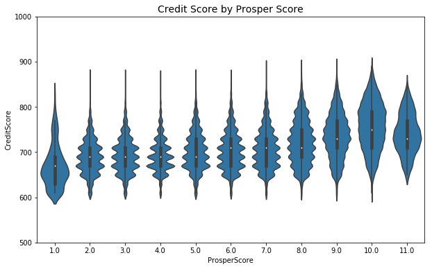

```python
plt.figure(figsize=(10, 6))
sb.violinplot(x= 'ProsperScore', y ='CreditScore', data = df_copy, scale ='width', color = base_color )
plt.title('Credit Score by Prosper Score', fontsize=14)
plt.ylim(500,1000);
```

ProsperScores within the range of 2.0-8.0 tend to have a lot of variation within the distribution of the CreditScore. I am a little surprised that a ProsperScore of 1.0 does not have CreditScore's that fall near 500. But at the same time, Experian considers a score below 580 to be "bad credit."- https://www.experian.com/blogs/ask-experian/what-is-the-lowest-credit-score/

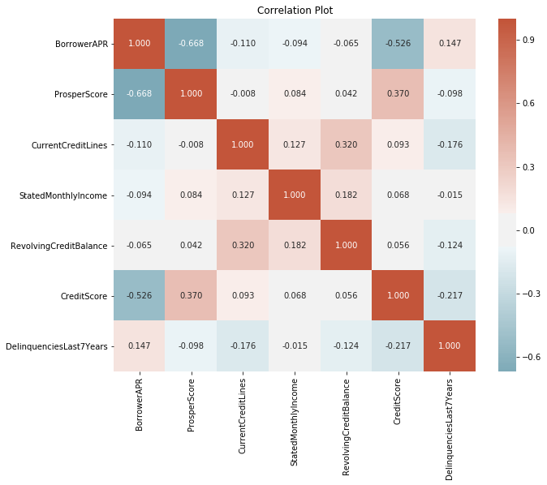

```python
# correlation plot
cmap = sb.diverging_palette(220, 20, sep=20, as_cmap=True)
num_vars = ['BorrowerAPR', 'ProsperScore', 'CurrentCreditLines',
            'StatedMonthlyIncome', 'RevolvingCreditBalance', 'CreditScore','DelinquenciesLast7Years']

plt.figure(figsize = [10, 8])
sb.heatmap(df_copy[num_vars].corr(), annot = True, fmt = '.3f',
           cmap = cmap, center = 0)
plt.title('Correlation Plot')
plt.show()
```

## Multivariate Exploration

To look deeper into this, we are going to analyze how the interest rate changed over years for Homeowners vs Non-Homeowners. A boxplot is used because it can be easily analyzed in a clean fashion.

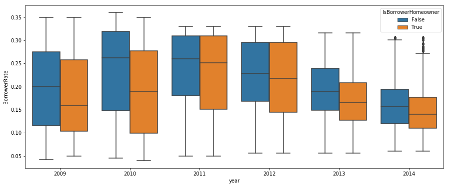

```python
# plots the boxplot to analyze homeowner's and non-homeowner's rate over years

b = sb.boxplot(data=df_copy, x='year', y='BorrowerRate', hue='IsBorrowerHomeowner');
b.figure.set_figwidth(15)
b.figure.set_figheight(6);
```

We can see that the borrower rate of a non-homewoner is typically higher than that of a homeowner. The interesting details in this plot is the trend of the homeowners rate. We can see that from 2009-2011 the homeowners interest rate continued to rise until it met the rate of non-homeowners. One thought to why this may have occured is the credit crisis that occurred from 2006–2007, which resulted in the bursting of the housing market. This definitely definitely increased homeowners interest rates. Prior to 2006, many homeowners were buying houses at high variable mortgage rates and when the market crashed, their houses greatly devalued. The bursting of the housing bubble is an important cause of the 2007–2009 recession in the United States and also caused foreclosure rates in 2006–2007 to greatly increase. This might not be the entire story but it would be worth investigating further.

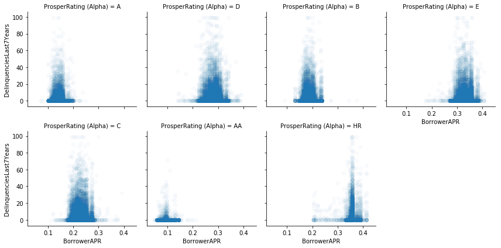

```python
b = sb.FacetGrid(data = df_copy, col = 'ProsperRating (Alpha)', col_wrap = 4, height = 3)
b.map(plt.scatter, 'BorrowerAPR', 'DelinquenciesLast7Years', alpha = 0.025)
b.set_xlabels('BorrowerAPR')
b.set_ylabels('DelinquenciesLast7Years');
```

This FacetGrid visualization helps to analyze BorrowerAPR vs DelinquenciesLast7Years on difference letter ratings. The lowerest rating(HR) of borrowers have the highest APR, but not it isn't that much worse than listings with rating(E). For high rating A(A), the borrowers has the lowers APR. This scatterplot visualization is really only helpfull when reducing the opacity.